# NOAA Storm Database Analysis

kuriboh

7/21/2020

# An analysis on impact of differrent types of natural disaster on economy and population’s health in the US.

This analysis bases on the U.S. National Oceanic and Atmospheric Administration’s (NOAA) storm database. This database tracks characteristics of major storms and weather events in the United States. This will focus on analyzing how natural disasters affected the society in the US in the period of 1950-2011. About the consequence in people’s heath, the number of direct / indirect deaths and injuries cases reported is report. The impact in economy is calculated as total damage on properties, crops, and is reported in USD unit.

### Data processing

- The following packages are required for this analysis

```r
required_packages <- c('dplyr', 'ggplot2')
for (package in required_packages) {
    if (!package %in% rownames(installed.packages())) {
        install.packages(package)
    }
}
library(dplyr)
library(ggplot2)
```

- The data is downloaded from the following URL and saved locally.

```r
data_url <- 'https://d396qusza40orc.cloudfront.net/repdata%2Fdata%2FStormData.csv.bz2'
file_path <- 'raw_data/compressed.csv.bz2'

raw_data_description <- 'https://d396qusza40orc.cloudfront.net/repdata%2Fpeer2_doc%2Fpd01016005curr.pdf'

download.file(data_url, file_path)
download.file(raw_data_description, 'raw_data/data_description.pdf')
```

- This code is used to read data into memory.

```r
storm_data <- read.csv(file_path)
```

- As the main purpose of the analysis, the following columns will be discarded to minimize the processed data.

```r
discarded_columns <- c('REMARKS', 'REFNUM', 'LATITUDE', 'LONGITUDE',
                       'LATITUDE_E', 'LONGITUDE_', 'ZONENAMES', 'STATEOFFIC',
                       'WFO', 'BGN_TIME', 'TIME_ZONE', 'COUNTY', 'COUNTYNAME',
                       'END_TIME', 'COUNTY_END', 'COUNTYENDN', 'END_RANGE',
                       'END_LOCATI', 'BGN_RANGE', 'BGN_LOCATI', 'BGN_AZI',
                       'END_AZI', 'LENGTH', 'WIDTH', 'STATE__', 'MAG', 'F',
                       'BGN_DATE', 'END_DATE', 'STATE'
)

for (colname in discarded_columns) {
    storm_data[colname] <- NULL
}
```

- The classes of event that appeared in the data set is defined as following, the same-referring events are put into the same vector.

```r
original_event_types <- list('tornado', 'hail', 'rain', 'snow', 'storm', 'dry',
                             'sleet', 'cloud', 'thunder', 'lightning', 'flood',
                             'drizzle', 'drought', 'frost', 'cold', 'eruption',
                             'fog', 'dust', 'waterspout', 'blizzard', 'tsunami',
                             c('wind', 'gust'),
                             c('tidal', 'tide'),
                             c('erosion', 'erosin'),
                             c('avalanche', 'avalance'),
                             c('tide', 'wave', 'surge'),
                             c('hurricane', 'whirlwind', 'typhoon'),
                             c('landslump', 'landslide', 'mudslide')
                          )
```

- The new data set is constructed as defined event types above. Any original event type (EVTYPE) that have any event’s name as sub-string are consider being one of that event.

```r
# Convert all character to lower case
storm_data$EVTYPE <- tolower(storm_data$EVTYPE)
storm_data$PROPDMGEXP <- tolower(storm_data$PROPDMGEXP)
storm_data$CROPDMGEXP <- tolower(storm_data$CROPDMGEXP)

construct_new_data <- function (other_storm_data) {
    new_variable_name <- 'event_type'
    new_storm_data <- list()
    counter <- 1

    for (i in 1:nrow(other_storm_data)) {
        key_words <- strsplit(other_storm_data[i, 'EVTYPE'],
                              paste(c('/', ' '), collapse = '|'))
        # Consider all event class
        for (original_event_type in original_event_types) {
            found <- F
            # Consider all event's name of that class
            for (my_type in original_event_type) {
                # If that original event type contains the keyword, then this event is one of the current class of event
                if (my_type %in% key_words) {
                    found = T
                    break
                }
            }
            # The current row is classified into event classes here
            if (found) {
                # Discard the first column (EVTYPE)
                new_row <- other_storm_data[i, -1]
                # Add event class
                new_row[new_variable_name] <- original_event_type[[1]][1]
                # Add to the new data set
                new_storm_data[[counter]] <- new_row
                counter <- counter + 1
            }
        }
    }
    dplyr::bind_rows(new_storm_data)
}

system.time(new_storm_data <- construct_new_data(storm_data))
```

```
##    user  system elapsed
## 809.257  56.213 865.752
```

- The data for analyzing heath impact is formed there. The new data set will contain 3 columns, event’s type, number of deaths / injuries, and the status (dead, or just injuried).

```r
create_heath_data <- function (input_data) {
    heath_properties <- input_data[, c('FATALITIES', 'INJURIES', 'event_type')]
    fatalities <- heath_properties[, c('FATALITIES', 'event_type')]
    # All statuses are fatalities
    fatalities$heath_type <- rep('fatalities', nrow(heath_properties))
    names(fatalities) <- c('count', 'event_type', 'heath_type')

    injuries <- heath_properties[, c('INJURIES', 'event_type')]
    # All statuses are injuries
    injuries$heath_type <- rep('injuries', nrow(heath_properties))
    names(injuries) <- c('count', 'event_type', 'heath_type')

    # Bind injuries and deaths by row into a new data set
    rbind(fatalities, injuries)
}
heath_data <- create_heath_data(new_storm_data)
```

- About economic consequence, the damage is calculated as sum of properties damage with crop damage.

```r
system.time(
    economic_data <- apply(new_storm_data, MARGIN = 1, function (row) {
        # 'k', 'm', 'b' means '1000', '1000000', '1000000000' respectively, as the properties and crop damages were written as unit (in the PROPDMG and CROPDMG) and suffix 'k', 'b', 'm' (in the PROPDMGEXP and CROPDMGEXP).
        calc_exp <- function (ch) {
            if (ch == 'k') {
                return (1e3)
            } else {
                if (ch == 'm') {
                    return (1e6)
                } else {
                    if (ch == 'b') {
                        return (1e9)
                    } else {
                        return (0)
                    }
                }
            }
        }
        calc_origin <- function (num) {
            if (!is.na(as.numeric(num))) {
                return (as.numeric(num))
            }
            return (0)
        }

        economic_damage <- calc_origin(row[['PROPDMG']]) * calc_exp(row[['PROPDMGEXP']]) +
                           calc_origin(row[['CROPDMG']]) * calc_exp(row[['CROPDMGEXP']])

        data.frame(event_type = row[['event_type']], damage = economic_damage)
    }) %>%
        dplyr::bind_rows()
)
```

```
##    user  system elapsed
## 325.211   4.794 330.117
```

### Results

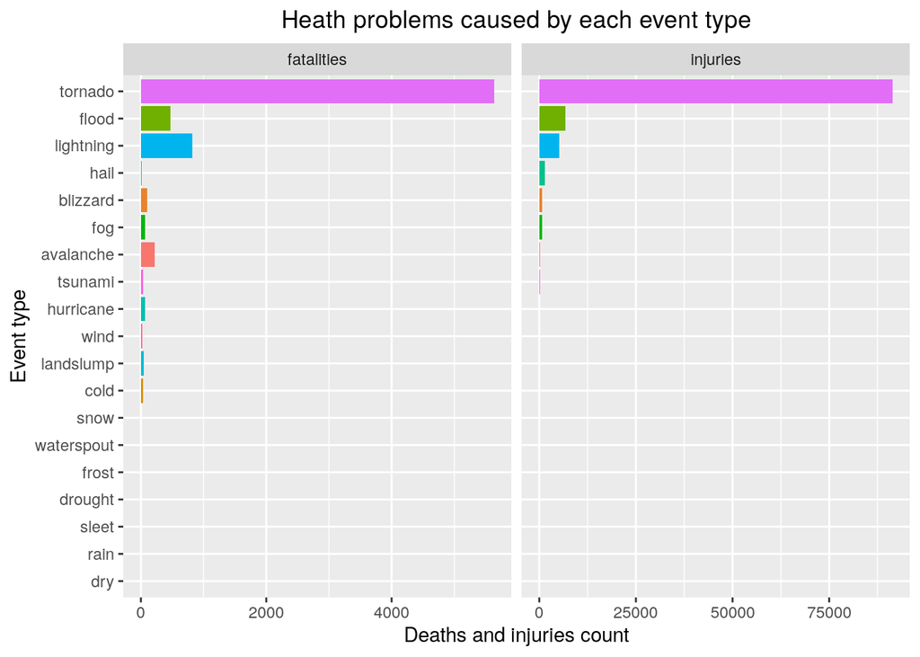

```r
heath_data_set <- aggregate(formula = count ~ event_type + heath_type,
                            data = heath_data,
                            FUN = sum, na.rm = T)
with(heath_data_set,
        ggplot2::ggplot(heath_data_set,
                        aes(x = reorder(event_type, count),
                            y = count,
                            fill = event_type)
        ) +
        ggplot2::coord_flip() +
        ggplot2::geom_bar(stat = 'identity') +
        ggplot2::ggtitle('Heath problems caused by each event type') +
        ggplot2::labs(x = 'Event type', y = 'Deaths and injuries count') +
        ggplot2::theme(legend.position = 'none',
                       plot.title = element_text(hjust = 0.5)) +
        ggplot2::facet_grid(. ~ heath_type, scales = 'free_x')
)
```

```r
heath_data_set
```

```
##    event_type heath_type count
## 1   avalanche fatalities   225
## 2    blizzard fatalities   101
## 3        cold fatalities    38
## 4     drought fatalities     0
## 5         dry fatalities     0
## 6       flood fatalities   470
## 7         fog fatalities    62
## 8       frost fatalities     1
## 9        hail fatalities    15
## 10  hurricane fatalities    62
## 11  landslump fatalities    42
## 12  lightning fatalities   816
## 13       rain fatalities     0
## 14      sleet fatalities     2
```

[output cut: 24 more lines]

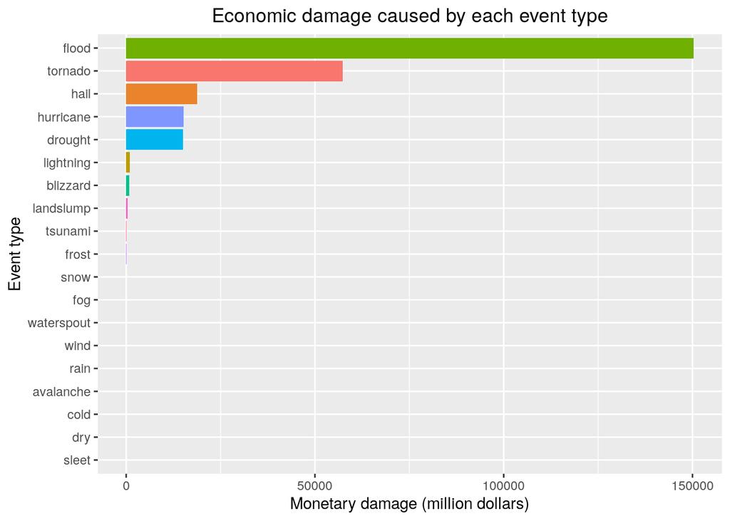

```r
sum_damage_by_event <- aggregate(damage ~ event_type,
                                 data = economic_data,
                                 FUN = sum)
# Calculate as million dollars
sum_damage_by_event$damage <- round(sum_damage_by_event$damage / 1e6, 2)

with(sum_damage_by_event,
        ggplot2::ggplot(sum_damage_by_event,
                        aes(x = reorder(event_type, damage),
                            y = damage,
                            fill = event_type)) +
        ggplot2::coord_flip() +
        ggplot2::geom_bar(stat = 'identity') +
        ggplot2::ggtitle('Economic damage caused by each event type') +
        ggplot2::labs(x = 'Event type', y = 'Monetary damage (million dollars)') +
        ggplot2::theme(legend.position = 'none',
                       plot.title = element_text(hjust = 0.5))
)
```

```r
sum_damage_by_event
```

```
##    event_type    damage
## 1     tornado  57352.11
## 2        hail  18758.22
## 3        snow     14.84
## 4   lightning    940.75
## 5        wind      8.99
## 6       flood 150319.68
## 7        cold      0.55
## 8  waterspout      9.35
## 9    blizzard    771.27
## 10  avalanche      3.72
## 11      sleet      0.00
## 12    drought  15018.67
## 13        dry      0.00
## 14  hurricane  15211.30
## 15      frost     66.02
## 16        fog     13.16
## 17       rain      6.05
## 18  landslump    346.46
## 19    tsunami    144.08
```